# Homework 2

Michael Egle; GitHub: michaelegle

2/5/2020

This homework is about syntax and basic plotting functions in R, and is **due by the end of Feb 7**.

You can use the RMarkDown file with these homework instructions as a template for your work. Make sure to replace “Your Name” and “your_github_username” in the YAML with your name and Github username.

**Submission instructions**: Create a folder named `ds202_hw2`, and name the RMarkDown file including your solutions `hw2.Rmd` under this folder. For submission, create a GitHub repository named `ds202_hw2` under your account, and push both `hw2.Rmd` and the knitted `hw2.html` to GitHub before the deadline. I will assume you use the same GitHub username as for your HW1 submission. The latest version of your homework appearing on GitHub before the deadline is graded. *It is crucial to follow the exact folder structure and file names*, so that your homework can be reproduced and graded by an automated script. Some questions will require the following answer format.

## Example question and answer

0. What is the smallest positive odd integer? Storage it in a variable named `a0` and print it.

**Example answer**: In the RMarkDown file, type in

````
```{r}
a0 <- 1
a0
```
````

The knitted html file will show:

```r
a0 <- 1
a0
```

```
## [1] 1
```

## R commands

1. Today’s temperature has a high of 24 and a low of 15 degree fahrenheit. Find the corresponding degress in celsius and storage it in a (single) vector named `cel`. Print the variable.

```r
cel <- c(-4.444, -9.444)
cel
```

```
## [1] -4.444 -9.444
```

2. Create a vector of length 200. The odd entries should be 3 and even entries should be 1. Storage the created in a variable named `vec200` and print.

```r
vec200 <- vector()
for (i in 1:200)
{
  if (i %% 2 == 1)
  {
    vec200 <- c(vec200, 3)
  }
  else
  {
    vec200 <- c(vec200, 1)
  }
}

vec200
```

```
##   [1] 3 1 3 1 3 1 3 1 3 1 3 1 3 1 3 1 3 1 3 1 3 1 3 1 3 1 3 1 3 1 3 1 3 1 3
##  [36] 1 3 1 3 1 3 1 3 1 3 1 3 1 3 1 3 1 3 1 3 1 3 1 3 1 3 1 3 1 3 1 3 1 3 1
##  [71] 3 1 3 1 3 1 3 1 3 1 3 1 3 1 3 1 3 1 3 1 3 1 3 1 3 1 3 1 3 1 3 1 3 1 3
## [106] 1 3 1 3 1 3 1 3 1 3 1 3 1 3 1 3 1 3 1 3 1 3 1 3 1 3 1 3 1 3 1 3 1 3 1
## [141] 3 1 3 1 3 1 3 1 3 1 3 1 3 1 3 1 3 1 3 1 3 1 3 1 3 1 3 1 3 1 3 1 3 1 3
## [176] 1 3 1 3 1 3 1 3 1 3 1 3 1 3 1 3 1 3 1 3 1 3 1 3 1
```

3. How many perfect squares are there between 1 and 2001? Storage the answer in a variable named `numPerfect` and print. You may want to look at `?round`.

```r
numPerfect <- vector()
for (i in 1:2001)
{
  if (sqrt(i) == round(sqrt(i)))
  {
    numPerfect <- c(numPerfect, i)
  }
}

numPerfect
```

```
##  [1]    1    4    9   16   25   36   49   64   81  100  121  144  169  196
## [15]  225  256  289  324  361  400  441  484  529  576  625  676  729  784
## [29]  841  900  961 1024 1089 1156 1225 1296 1369 1444 1521 1600 1681 1764
## [43] 1849 1936
```

```r
length(numPerfect)
```

```
## [1] 44
```

There are 44 perfect squares from 1 to 2001

## Cars and mileage

For this part we will use the `mpg` data set, you can access the data by first installing (using `install.packages('ggplot2')`) and then loading the package `ggplot2` (using `library(ggplot2)`) into your R session. The `mpg` data includes information about fuel economy of popular car models for the years 1999 and 2008 as collected by the US Environmental Protection Agency. An answer should include a short paragraph of text for the explanation to a (human) reader, together with appropriate R code, outputs, and graphs.

Most exercises are from the ggplot2 book section 2.2.1. You might find it helpful for working on the homework to read through this section. *However, all questions can be solved by using just the basic R graphics functions.*

```r
library(ggplot2)
library(tidyverse)
```

1. What are the 3 most fuel-efficient models in terms of highway mileage? Storage the data frame (with 3 rows) containing all information of these three cars in a variable named `top3` and print.

```r
mpg %>%
  arrange(desc(hwy)) %>%
  head(3) -> top3

top3
```

```
## # A tibble: 3 x 11
##   manufacturer model  displ  year   cyl trans drv     cty   hwy fl    class
##   <chr>        <chr>  <dbl> <int> <int> <chr> <chr> <int> <int> <chr> <chr>
## 1 volkswagen   jetta    1.9  1999     4 manu… f        33    44 d     comp…
## 2 volkswagen   new b…   1.9  1999     4 manu… f        35    44 d     subc…
## 3 volkswagen   new b…   1.9  1999     4 auto… f        29    41 d     subc…
```

Volkswagen has the three most fuel efficient cars in terms of highway mileage. The 1999 Jetta and 1999 New Beetle with either automatic or manual transmission have the highest highway mileage.

2. How many different compact models are included in this dataset? Storage the answer in a variable named `numCompact` and print.

```r
mpg %>%
  filter(class == "compact") %>%
  count() -> numCompact

numCompact
```

```
## # A tibble: 1 x 1
##       n
##   <int>
## 1    47
```

There are 47 compact models in this dataset

3. Create a scatterplot of `hwy` and `cty` and describe the relationship. Why are there so few points visible? Explain your findings.

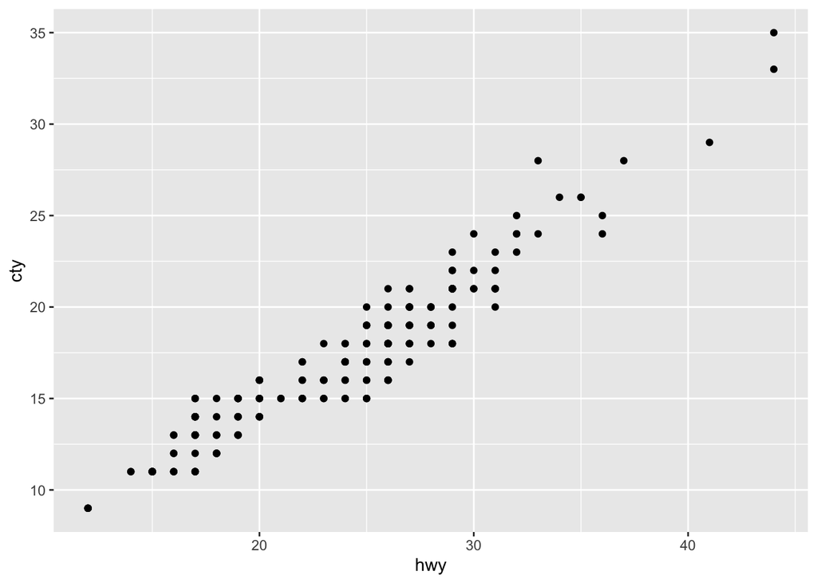

```r
mpg %>%
  ggplot(aes(x = hwy, y = cty)) +
  geom_point()
```

There are few points visible because the values for hwy and cty are discrete values rather than continuous. Also, some of the data points could be shared between many cars which leads to fewer visible data points on the plot.

4. Are cars in 2008 more fuel efficient than cars in 1999? Use graphs *and* summary statistics to answer this question. Explain your findings.

```r
mpg %>%
  filter(year == 2008) -> mpg08
mpg %>%
  filter(year == 1999) -> mpg99

summary(mpg08$cty)
```

```
##    Min. 1st Qu.  Median    Mean 3rd Qu.    Max.
##     9.0    13.0    17.0    16.7    20.0    28.0
```

```r
summary(mpg99$cty)
```

```
##    Min. 1st Qu.  Median    Mean 3rd Qu.    Max.
##   11.00   14.00   17.00   17.02   19.00   35.00
```

For the most part, there isn’t much difference between the two years in terms of city gas mileage. The only major difference is that the highest observation in 1999 (35 mpg) is much higher than that of 2008 (28 mpg).

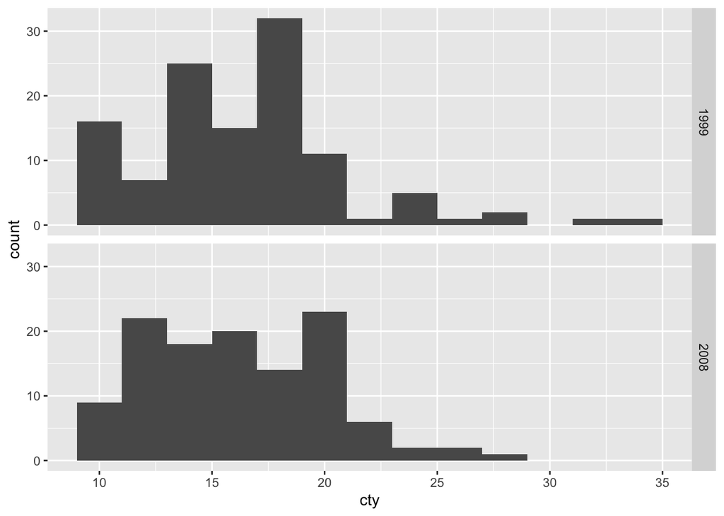

```r
mpg %>%
  filter(year == 1999 | year == 2008) %>%
  ggplot(aes(cty)) +
  geom_histogram(binwidth = 2) +
  facet_grid(year ~ .)
```

The histograms show that the cars in 1999 had more outliers while 2008 is more uniformly distributed

```r
summary(mpg08$hwy)
```

```
##    Min. 1st Qu.  Median    Mean 3rd Qu.    Max.
##   12.00   18.00   24.00   23.45   28.00   37.00
```

```r
summary(mpg99$hwy)
```

```
##    Min. 1st Qu.  Median    Mean 3rd Qu.    Max.
##   15.00   17.00   25.00   23.43   26.00   44.00
```

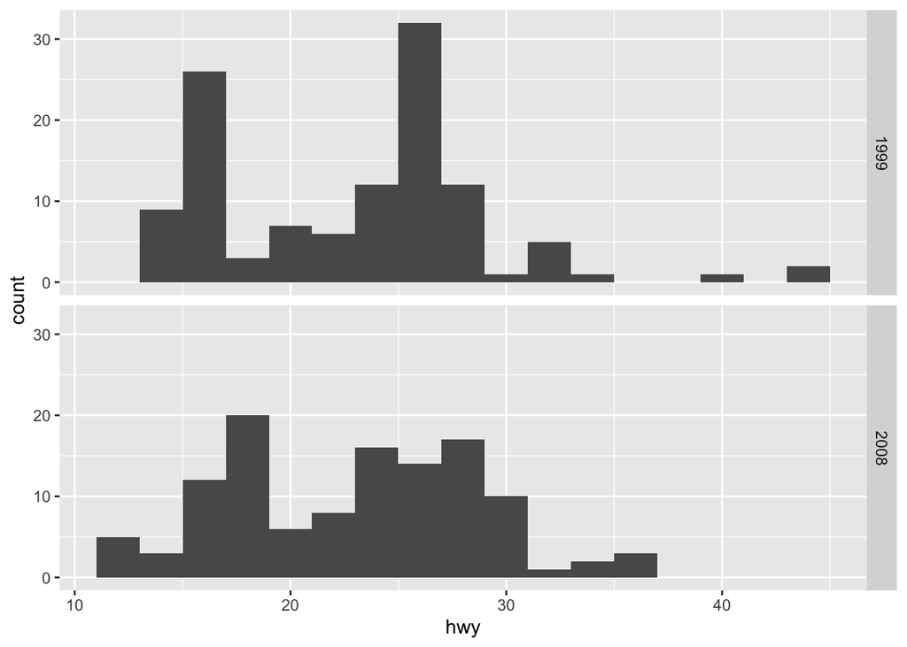

```r
mpg %>%
  filter(year == 1999 | year == 2008) %>%
  ggplot(aes(hwy)) +
  geom_histogram(binwidth = 2) +
  facet_grid(year ~ .)
```

This distribution looks similar to what appeared in the first histogram. There are a couple of spikes in the 1999 distribution and a few more outliers where 2008 is closer to being a uniform distribution.

In conclusion, I’d say that there’s no clear cut answer as to which year’s cars were more efficient. However if I had to choose, I’d say that 1999’s were more efficient by a small margin

Note: your submission is supposed to be fully reproducible, i.e. the TA and I will ‘knit’ your submission. Make sure that you don’t use any file structure that depends on your computing environment.